# Lesson 3

#### Think about a time when you posted a specific message or shared a photo on Facebook. What was it?

Response:

#### How many of your friends do you think saw that post?

Response:

#### Think about what percent of your friends on Facebook see any posts or comments that you make in a month. What percent do you think that is?

Response:

### Perceived Audience Size

Notes:

### Faceting

Notes:

#### Let’s take another look at our plot. What stands out to you here?

Response:

### Be Skeptical - Outliers and Anomalies

Notes:

### Moira’s Outlier

Notes: #### Which case do you think applies to Moira’s outlier? Response:

### Friend Count

Notes:

#### What code would you enter to create a histogram of friend counts?

#### How is this plot similar to Moira’s first plot?

Response:

### Limiting the Axes

Notes:

### Exploring with Bin Width

Notes:

### Adjusting the Bin Width

Notes:

### Faceting Friend Count

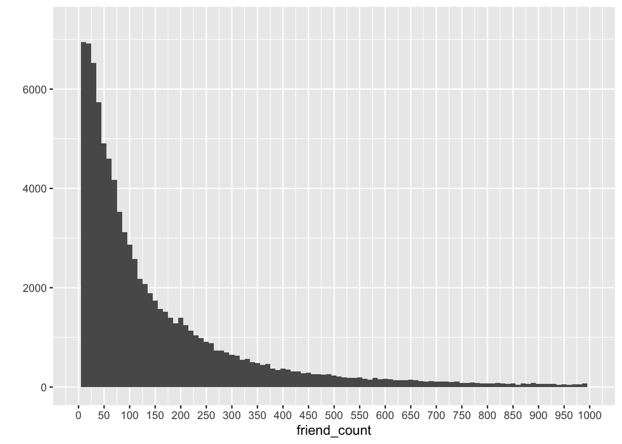

```r
# What code would you add to create a facet the histogram by gender?
# Add it to the code below.
qplot(x = friend_count, data = pf, binwidth = 10) +
  scale_x_continuous(limits = c(0, 1000),
                     breaks = seq(0, 1000, 50))
```

### Omitting NA Values

Notes:

### Statistics ‘by’ Gender

Notes:

#### Who on average has more friends: men or women?

Response:

#### What’s the difference between the median friend count for women and men?

Response:

#### Why would the median be a better measure than the mean?

Response:

### Tenure

Notes:

#### How would you create a histogram of tenure by year?

### Labeling Plots

Notes:

### User Ages

Notes:

#### What do you notice?

Response:

### The Spread of Memes

Notes:

### Lada’s Money Bag Meme

Notes:

### Transforming Data

Notes:

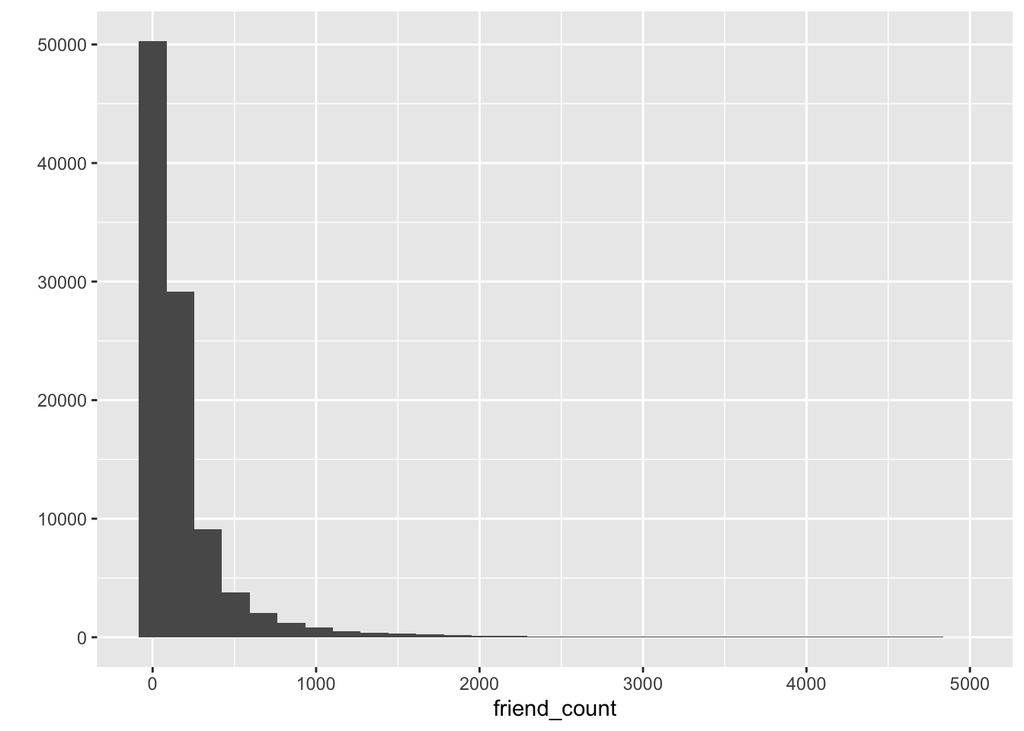

```r
qplot(x = friend_count, data = pf)
```

```r
summary(pf$friend_count)
```

```
##    Min. 1st Qu.  Median    Mean 3rd Qu.    Max.
##     0.0    31.0    82.0   196.4   206.0  4923.0
```

```r
summary(log10(pf$friend_count + 1))
```

```
##    Min. 1st Qu.  Median    Mean 3rd Qu.    Max.
##   0.000   1.505   1.919   1.868   2.316   3.692
```

```r
summary(sqrt(pf$friend_count))
```

```
##    Min. 1st Qu.  Median    Mean 3rd Qu.    Max.
##   0.000   5.568   9.055  11.088  14.353  70.164
```

```r
# install.packages('gridExtra')
library(gridExtra)
```

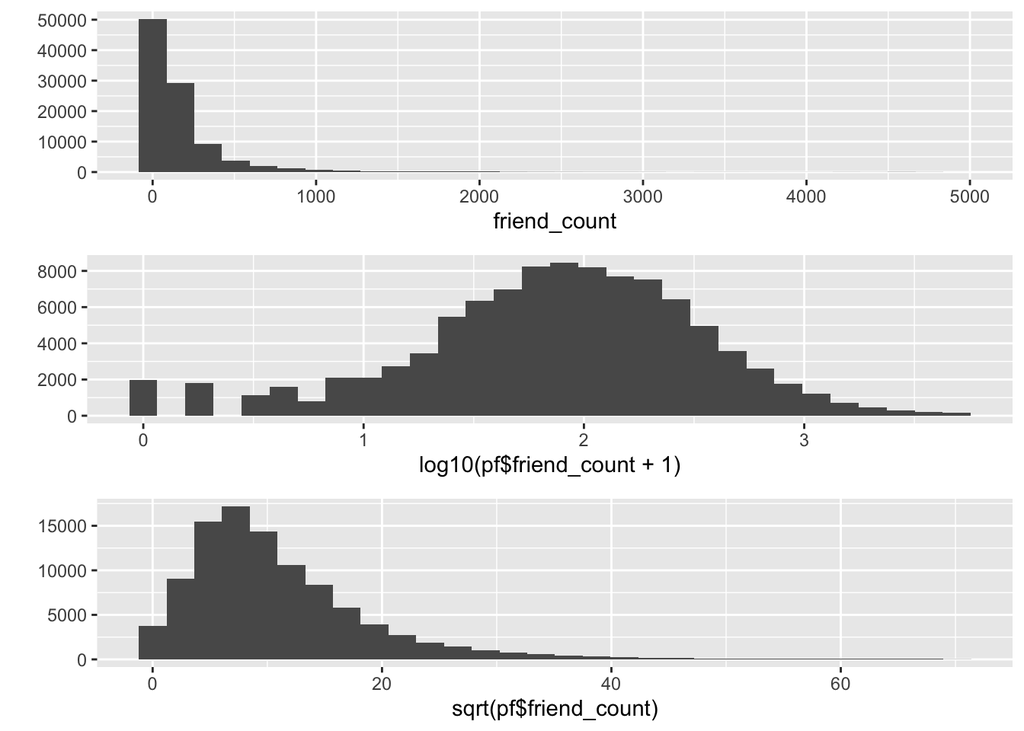

```r
# define individual plots
p1 = qplot(x = friend_count, data = pf)
p2 = qplot(log10(pf$friend_count + 1))
p3 = qplot(sqrt(pf$friend_count))
# arrange plots in grid
grid.arrange(p1, p2, p3, ncol=1)
```

# same as above but different syntax

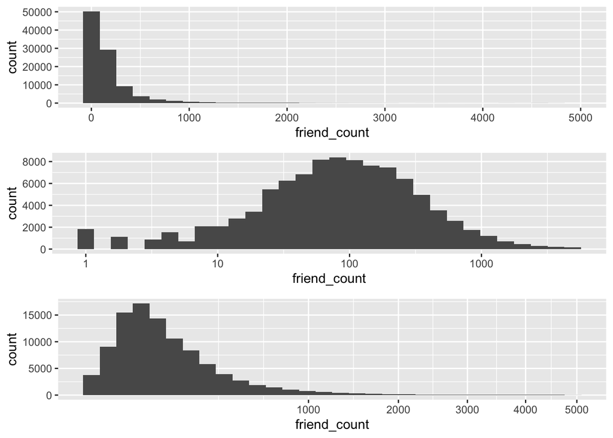

```r
p4 <- ggplot(aes(x = friend_count), data = pf) + geom_histogram()
p5 <- p4 + scale_x_log10()
p6 <- p4 + scale_x_sqrt()

grid.arrange(p4, p5, p6, ncol=1)
```

### Add a Scaling Layer

Notes:

### Frequency Polygons

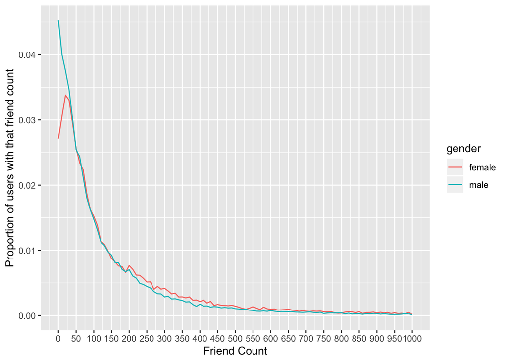

```r
qplot(x = friend_count, y = ..density../sum(..density..),
      data = subset(pf, !is.na(gender)),
      binwidth = 10,
      geom = 'freqpoly',
      color = gender) +
  scale_x_continuous(limits = c(0, 1000),
                     breaks = seq(0, 1000, 50)) +
  xlab('Friend Count') +
  ylab('Proportion of users with that friend count')
```

# ggplot(aes(x = friend_count, y = ..count../sum(..count..)),

# data = subset(pf, !is.na(gender))) +

# geom_freqpoly(aes(color = gender), binwidth=10) +

# scale_x_continuous(limits = c(0, 1000), breaks = seq(0, 1000, 50)) +

# xlab(‘Friend Count’) +

# ylab(‘Proportion of users with that friend count’)

# Equivalent ggplot syntax for solution video:

# ggplot(aes(x = www_likes), data = subset(pf, !is.na(gender))) +

# geom_freqpoly(aes(color = gender)) +

# scale_x_log10()

### Likes on the Web

Notes:

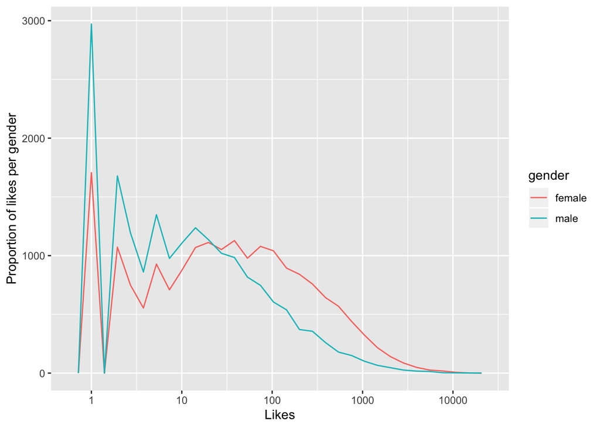

```r
 ggplot(aes(x = www_likes), data = subset(pf, !is.na(gender))) +
  geom_freqpoly(aes(color = gender)) +
  scale_x_log10() +
  xlab('Likes') +
  ylab('Proportion of likes per gender')
```

```r
by(pf$www_likes, pf$gender, sum)
```

```
## pf$gender: female
## [1] 3507665
## --------------------------------------------------------
## pf$gender: male
## [1] 1430175
```

### Box Plots

Notes:

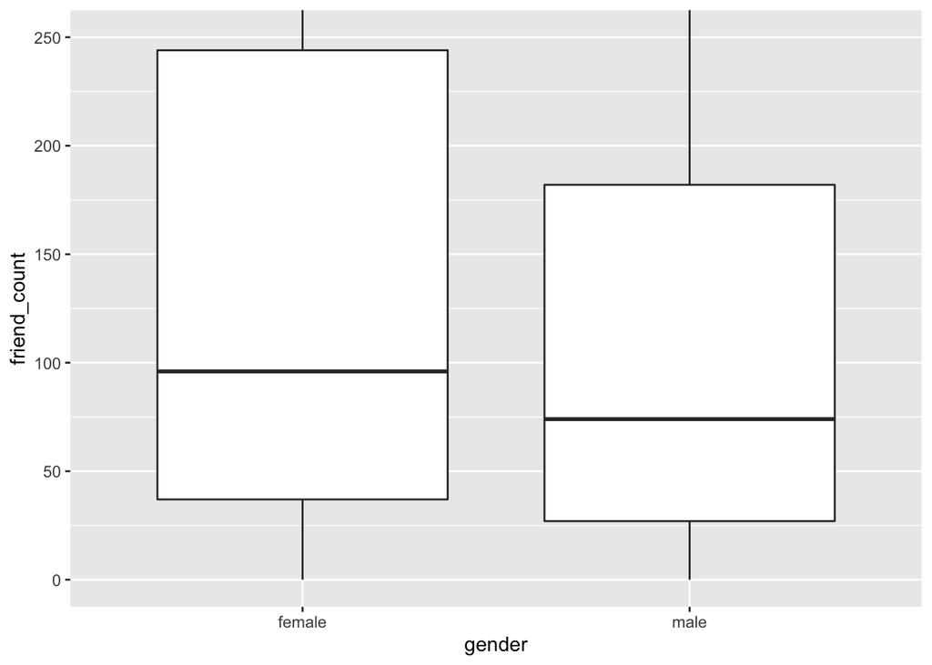

```r
qplot(x = gender, y = friend_count,
      data = subset(pf, !is.na(gender)),
      geom = 'boxplot') +
      coord_cartesian(ylim = c(0, 250))
```

```r
by(pf$friend_count, pf$gender, summary)
```

```
## pf$gender: female
##    Min. 1st Qu.  Median    Mean 3rd Qu.    Max.
##       0      37      96     242     244    4923
## --------------------------------------------------------
## pf$gender: male
##    Min. 1st Qu.  Median    Mean 3rd Qu.    Max.
##       0      27      74     165     182    4917
```

#### Adjust the code to focus on users who have friend counts between 0 and 1000.

### Box Plots, Quartiles, and Friendships

Notes:

#### On average, who initiated more friendships in our sample: men or women?

Response: #### Write about some ways that you can verify your answer. Response:

Response:

### Getting Logical

Notes:

```r
summary(pf$mobile_likes)
```

```
##    Min. 1st Qu.  Median    Mean 3rd Qu.    Max.
##     0.0     0.0     4.0   106.1    46.0 25111.0
```

```r
summary(pf$mobile_likes > 0)
```

```
##    Mode   FALSE    TRUE
## logical   35056   63947
```

```r
mobile_check_in <- NA
pf$mobile_check_in <- ifelse(pf$mobile_likes > 0, 1, 0)
pf$mobile_check_in <- factor(pf$mobile_check_in)
summary(pf$mobile_check_in)
```

```
##     0     1
## 35056 63947
```

Response:

```r
sum(pf$mobile_check_in == 1)/length(pf$mobile_check_in)
```

```
## [1] 0.6459097
```

### Analyzing One Variable

Reflection:

Click **KnitHTML** to see all of your hard work and to have an html page of this lesson, your answers, and your notes!